# Candy1

Czuee Morey

7/24/2019

##Business question

The Lidl purchasing group wants to expand its candy offering, and wants to create a brand new product. Based on data from existing brand products, the goal is to find out which product characteristics drive customer sentiment and subsequently make a recommendation on a new product.

Question 1: Which product characteristics are correlated with the highest customer sentiment?

Question 2: Recommend a new product based on these characteristics

## Get data and clean

#Read the file and get a look at the data

```r
candy <- read.csv("candy-data.csv", header = TRUE, na.strings = c("NA"," "))

# head(candy)
#
 summary(candy)
```

```
##             competitorname   chocolate          fruity
##  100 Grand         : 1     Min.   :0.0000   Min.   :0.0000
##  3 Musketeers      : 1     1st Qu.:0.0000   1st Qu.:0.0000
##  Air Heads         : 1     Median :0.0000   Median :0.0000
##  Almond Joy        : 1     Mean   :0.4353   Mean   :0.4471
##  Baby Ruth         : 1     3rd Qu.:1.0000   3rd Qu.:1.0000
##  Boston Baked Beans: 1     Max.   :1.0000   Max.   :1.0000
##  (Other)           :79
##     caramel       peanutyalmondy       nougat        crispedricewafer
##  Min.   :0.0000   Min.   :0.0000   Min.   :0.00000   Min.   :0.00000
##  1st Qu.:0.0000   1st Qu.:0.0000   1st Qu.:0.00000   1st Qu.:0.00000
##  Median :0.0000   Median :0.0000   Median :0.00000   Median :0.00000
##  Mean   :0.1647   Mean   :0.1647   Mean   :0.08235   Mean   :0.08235
##  3rd Qu.:0.0000   3rd Qu.:0.0000   3rd Qu.:0.00000   3rd Qu.:0.00000
##  Max.   :1.0000   Max.   :1.0000   Max.   :1.00000   Max.   :1.00000
##
##       hard             bar            pluribus       sugarpercent
##  Min.   :0.0000   Min.   :0.0000   Min.   :0.0000   Min.   :0.0110
##  1st Qu.:0.0000   1st Qu.:0.0000   1st Qu.:0.0000   1st Qu.:0.2200
##  Median :0.0000   Median :0.0000   Median :1.0000   Median :0.4650
##  Mean   :0.1765   Mean   :0.2471   Mean   :0.5176   Mean   :0.4786
##  3rd Qu.:0.0000   3rd Qu.:0.0000   3rd Qu.:1.0000   3rd Qu.:0.7320
##  Max.   :1.0000   Max.   :1.0000   Max.   :1.0000   Max.   :0.9880
##
##   pricepercent      winpercent
##  Min.   :0.0110   Min.   :22.45
##  1st Qu.:0.2550   1st Qu.:39.14
##  Median :0.4650   Median :47.83
##  Mean   :0.4689   Mean   :50.32
##  3rd Qu.:0.6510   3rd Qu.:59.86
##  Max.   :0.9760   Max.   :84.18
##
```

```r
# dim(candy)
# table(candy$pluribus)
#
# identical(candy$competitorname, unique(candy$competitorname))
```

#Observations: 1. There are no NAs or missing values in the file. So, the dataset is complete and it is not required to clean any errors or missing values. 2 .Each column is “tidy”, that is each column represents a single variable 3. The variables chocolate to pluribus are binary, but are represented as integers. Needs to be corrected. 4. “sugarpercent” is a percentile value for the dataset, not percentage of sugar content. Same for “pricepercent”. 5. “winpercent” is the percentage of times the candy won in matchups (customer satisfaction) from the 269,000 matchups. It is the dependent variable. 6. Assumption: Competitor name is not a predictor (unless brand value drives sales) and is unique, so can be made the row name.

#Convert binary columns to factor

```r
candy[ , 2:10] <- lapply(candy[ , 2:10], factor)
sapply(candy, class)
```

```
##   competitorname        chocolate           fruity          caramel
##         "factor"         "factor"         "factor"         "factor"
##   peanutyalmondy           nougat crispedricewafer             hard
##         "factor"         "factor"         "factor"         "factor"
##              bar         pluribus     sugarpercent     pricepercent
##         "factor"         "factor"        "numeric"        "numeric"
##       winpercent
##        "numeric"
```

#Descriptive statistics for numeric variables

```r
describe(candy)
```

```
## # A tibble: 3 x 26
##   variable     n    na   mean     sd se_mean    IQR skewness kurtosis
##   <chr>    <dbl> <dbl>  <dbl>  <dbl>   <dbl>  <dbl>    <dbl>    <dbl>
## 1 sugarpe~    85     0  0.479  0.283  0.0307  0.512   0.0954   -1.13
## 2 pricepe~    85     0  0.469  0.286  0.0310  0.396   0.133    -1.15
## 3 winperc~    85     0 50.3   14.7    1.60   20.7     0.332    -0.580
## # ... with 17 more variables: p00 <dbl>, p01 <dbl>, p05 <dbl>, p10 <dbl>,
## #   p20 <dbl>, p25 <dbl>, p30 <dbl>, p40 <dbl>, p50 <dbl>, p60 <dbl>,
## #   p70 <dbl>, p75 <dbl>, p80 <dbl>, p90 <dbl>, p95 <dbl>, p99 <dbl>,
## #   p100 <dbl>
```

The distribution for the predictors is good with a defined mean (se_mean is low) and the sd is much lower than the mean. The skewness and kurtosis is low for the predictors, and no transformation is necessary.

###Exploratory Data Analysis #Best candies

```r
#summary(candy)
candy <- arrange(candy, desc(winpercent))
head(candy)
```

```
##               competitorname chocolate fruity caramel peanutyalmondy
## 1 ReeseÃ•s Peanut Butter cup         1      0       0              1
## 2        ReeseÃ•s Miniatures         1      0       0              1
## 3                       Twix         1      0       1              0
## 4                    Kit Kat         1      0       0              0
## 5                   Snickers         1      0       1              1
## 6            ReeseÃ•s pieces         1      0       0              1
##   nougat crispedricewafer hard bar pluribus sugarpercent pricepercent
## 1      0                0    0   0        0        0.720        0.651
## 2      0                0    0   0        0        0.034        0.279
## 3      0                1    0   1        0        0.546        0.906
## 4      0                1    0   1        0        0.313        0.511
## 5      1                0    0   1        0        0.546        0.651
## 6      0                0    0   0        1        0.406        0.651
##   winpercent
## 1   84.18029
## 2   81.86626
## 3   81.64291
## 4   76.76860
## 5   76.67378
## 6   73.43499
```

Reese’s candies seem to be very popular. Let’s look at what is the proportion of candies for each ingredient?

#Distribution of each variable

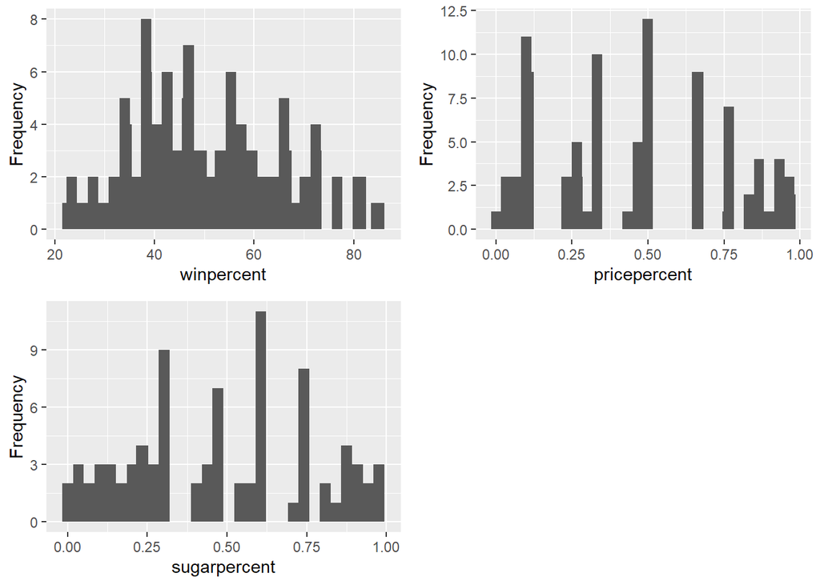

```r
win.h <- qplot(winpercent, data = candy, ylab = "Frequency") +stat_bin(binwidth = 1)
price.h <- qplot(pricepercent, data = candy, ylab = "Frequency") +stat_bin(binwidth = 0.01)
sugar.h <- qplot(sugarpercent, data = candy, ylab = "Frequency") +stat_bin(binwidth = 0.01)

grid.arrange(win.h, price.h, sugar.h, nrow = 2)
```

```r
#ggplot(candy, aes(pricepercent, winpercent)) +geom_point(aes(color = chocolate))
```

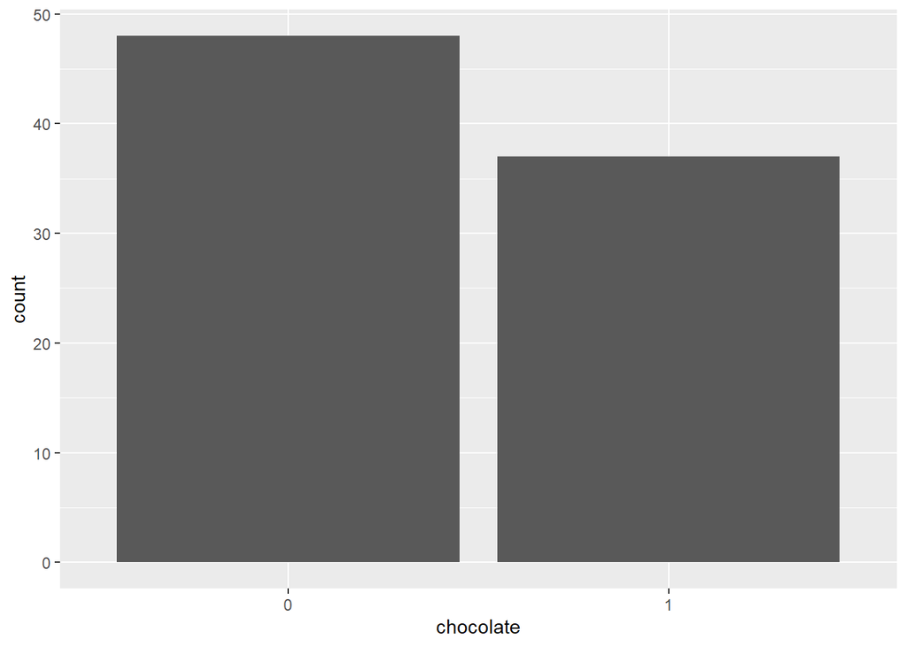

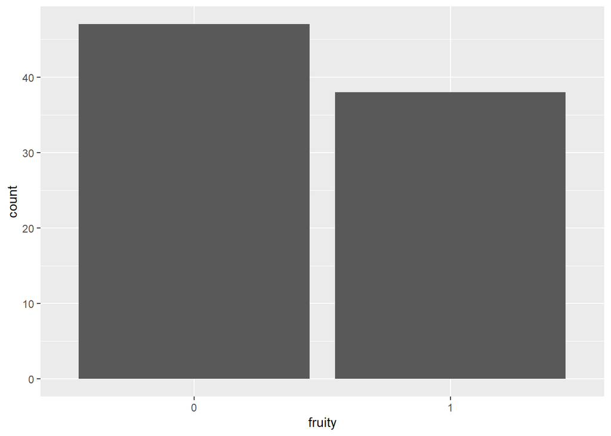

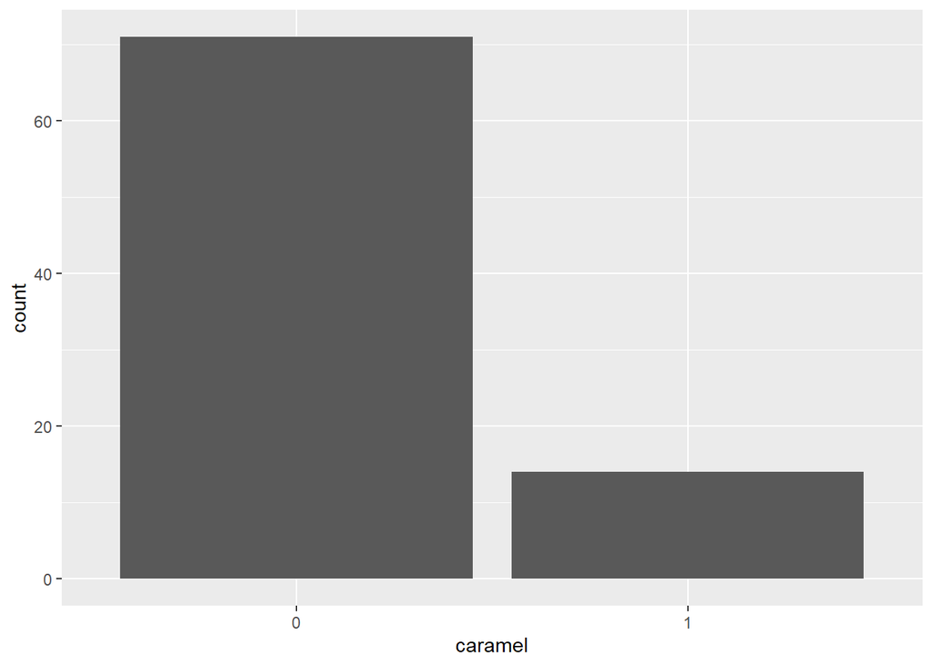

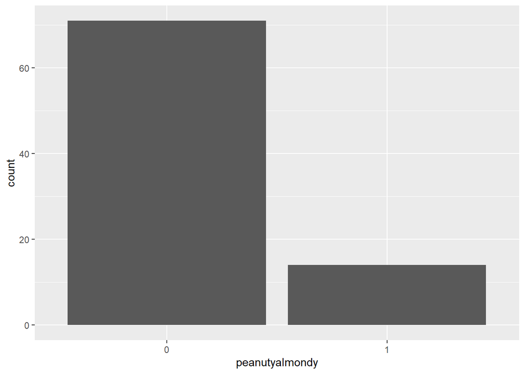

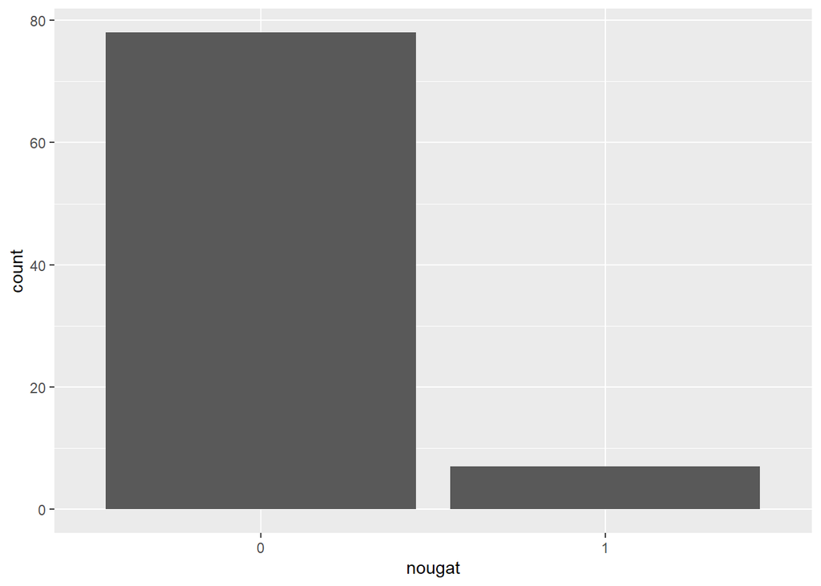

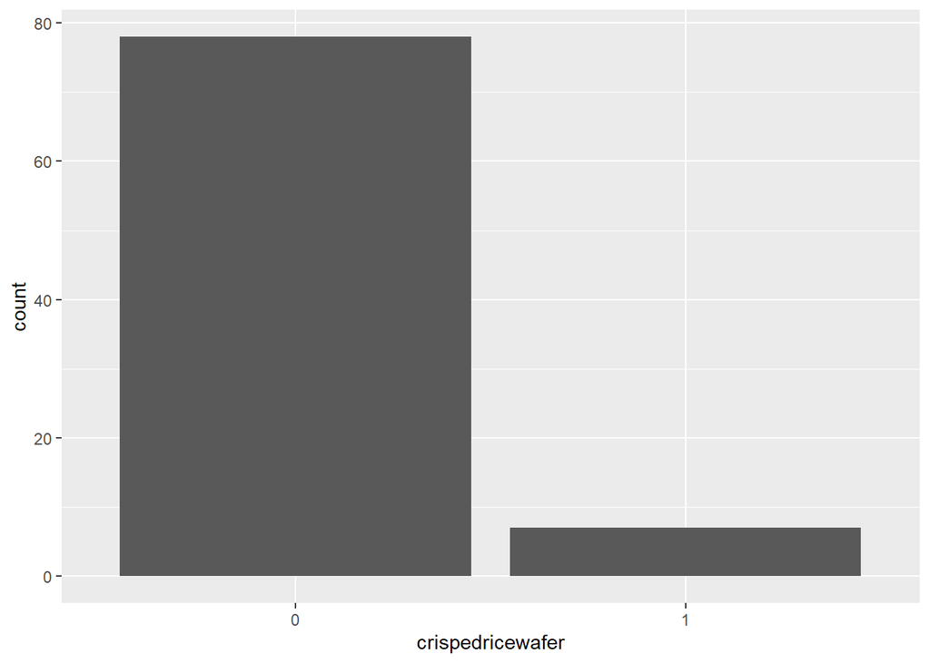

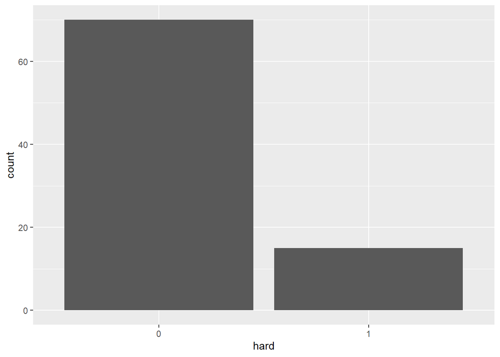

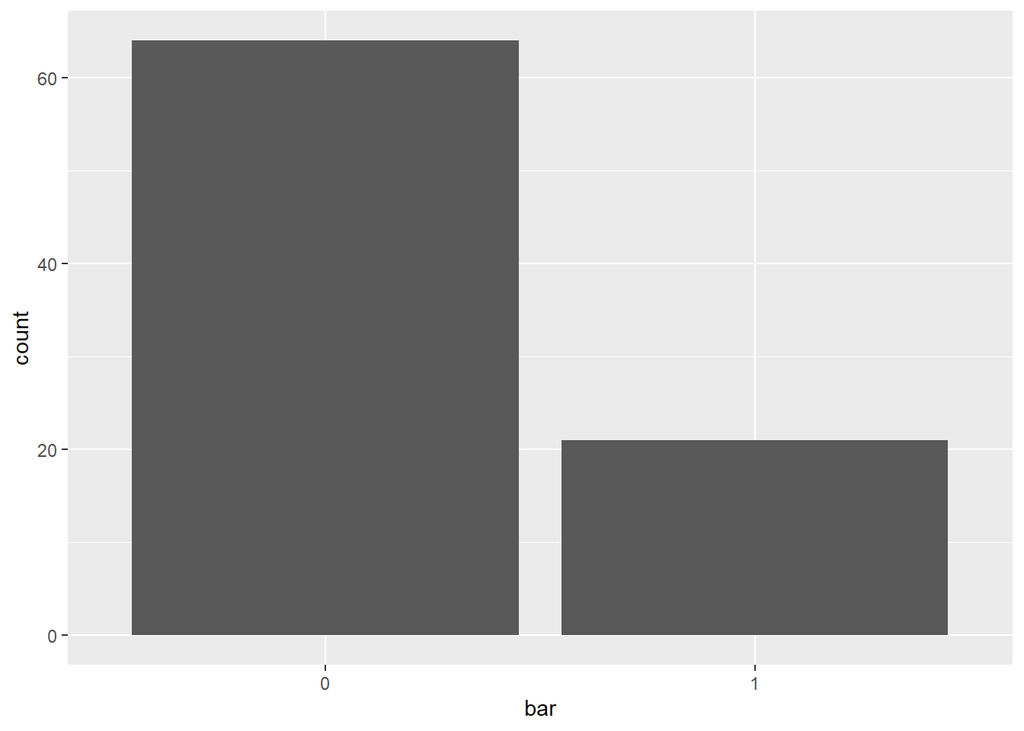

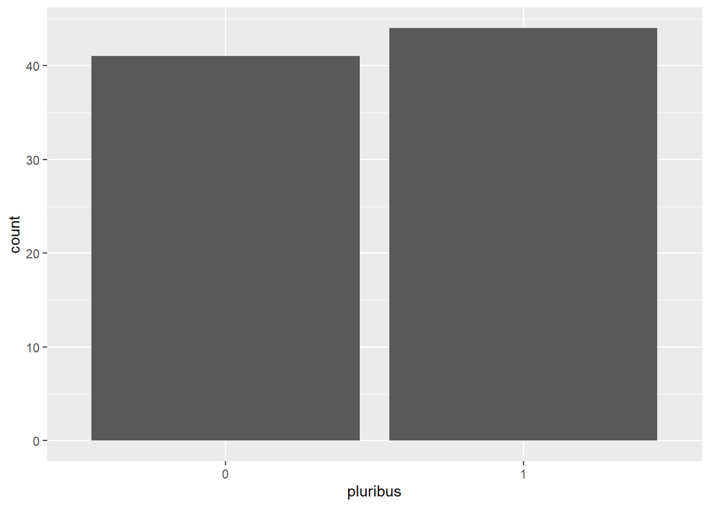

```r
nm <- names(candy[2:10])
for (i in seq_along(nm)) {
    bar <- ggplot(candy, aes_string(x = nm[i]))+ geom_bar()
    print(bar)
}
```

Chocolate and fruity each are present in >35% of candies while the other ingredients are in smaller quantities. More than 20% of candies are bars, and almost equal number of candies are single or present in a bag/box

#Only 1 candy has both chocolate and fruity - very low overlap!

```r
table(candy$chocolate, candy$fruity)
```

```
##
##      0  1
##   0 11 37
##   1 36  1
```

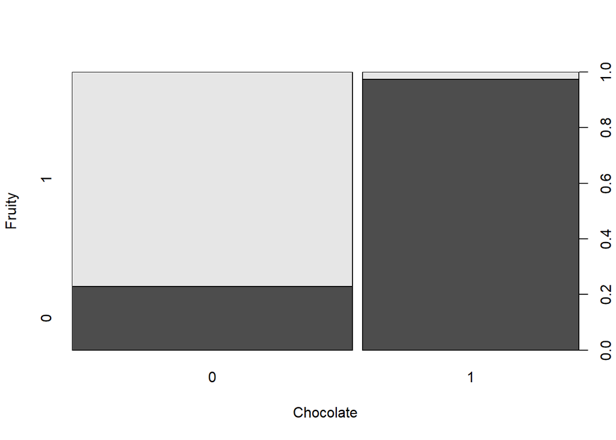

```r
plot(candy$chocolate, candy$fruity, xlab = "Chocolate", ylab = "Fruity")
```